# WEEK 3: Logistic regression

In this exercise I had a data set that included statistics on student’s social background, living place, education, alcohol consumption etc. versus student’s grades and absences in Mathematics and Portuguese language.

Related study: *P. Cortez and A. Silva. Using Data Mining to Predict Secondary School Student Performance. In A. Brito and J. Teixeira Eds., Proceedings of 5th FUture BUsiness TEChnology Conference (FUBUTEC 2008) pp. 5-12, Porto, Portugal, April, 2008, EUROSIS, ISBN 978-9077381-39-7.*

Web link: [http://www3.dsi.uminho.pt/pcortez/student.pdf]

```r
alc <- read.table("Data/alc.txt")
colnames(alc)
```

```
##  [1] "school"     "sex"        "age"        "address"    "famsize"
##  [6] "Pstatus"    "Medu"       "Fedu"       "Mjob"       "Fjob"
## [11] "reason"     "guardian"   "traveltime" "studytime"  "schoolsup"
## [16] "famsup"     "activities" "nursery"    "higher"     "internet"
## [21] "romantic"   "famrel"     "freetime"   "goout"      "Dalc"
## [26] "Walc"       "health"     "failures"   "paid"       "absences"
## [31] "G1"         "G2"         "G3"         "alc_use"    "high_use"
```

The data contains total 35 variables: both social and school related features. The most interesting variable related to student’s performance is ‘G3’, which is a mean of final year grades of Mathematics and Portuguese language. Attribute ‘alc_use’ equals to average alcohol consumption, and students having average consumption of higher than 2 were classified as high users (value TRUE at column ‘high_use’).

### Study questions:

Let’s examine if there are relationships between high/low alcohol consumption and student’s (1) **sex**, (2) **weekly study time**, (3) **extra-curricular activities** and (4) **final grade**. - I hypothesize that either sex or study time don’t relate on alcohol consumption, but I believe that having extra-curricular activities would decrease alcohol consumption. Also I believe that high alcohol use would decrease student’s final grade.

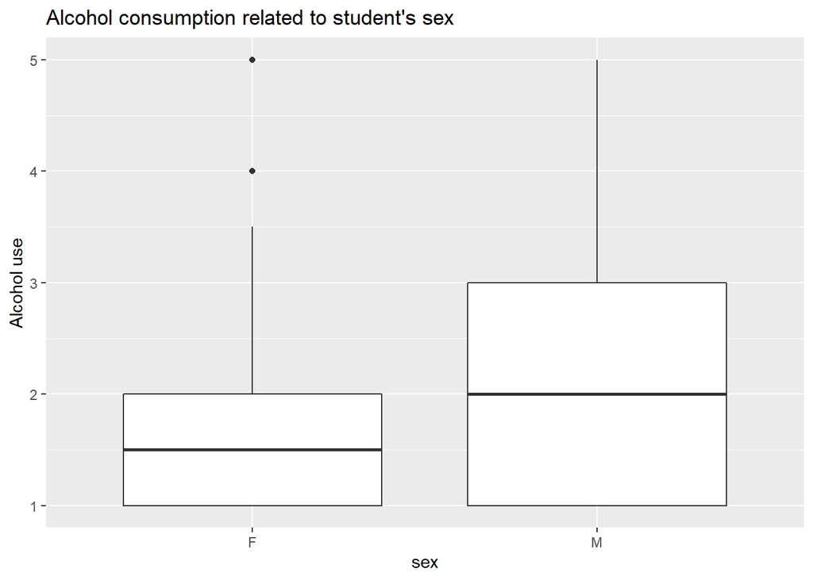

```r
# Explore relationship between sex and alcohol consumption:
g1 <- ggplot(alc, aes(x = sex, y = alc_use))
g1 + geom_boxplot() + ggtitle("Alcohol consumption related to student's sex") + ylab("Alcohol use")
```

Damn, I went totally wrong here, since according to the figure above male students consume significantly more alcohol than female students on average. Let’s then explore if weekly study time matters on alcohol use:

```r
# Explore relationship between weekly study time and alcohol consumption:
alc %>% group_by(studytime) %>% summarise(count = n(), alcohol = mean(alc_use))
```

```
## # A tibble: 4 x 3
##   studytime count alcohol
##       <int> <int>   <dbl>
## 1         1    98    2.27
## 2         2   185    1.86
## 3         3    60    1.52
## 4         4    27    1.54
```

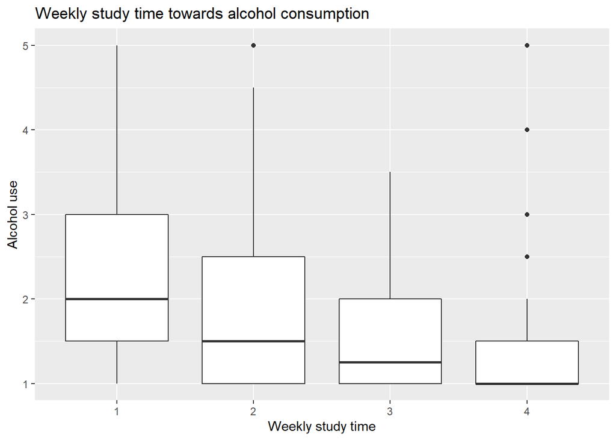

```r
g2 <- ggplot(alc, aes(x = factor(studytime), y = alc_use))
g2 + geom_boxplot() + ggtitle("Weekly study time towards alcohol consumption") + ylab("Alcohol use") + xlab("Weekly study time")
```

The criteria: 1 = <2 hours, 2 = 2 to 5 hours, 3 = 5 to 10 hours, or 4 =- >10 hours.

So, the less they study, the more they drink. Or the more they drink, the less they study? I cannot know if there exists a causal relationship between study time and alcohol consumption, but in any case the figure above points out that on average people using more time for studying are drinking less. How about extra-curricular activities:

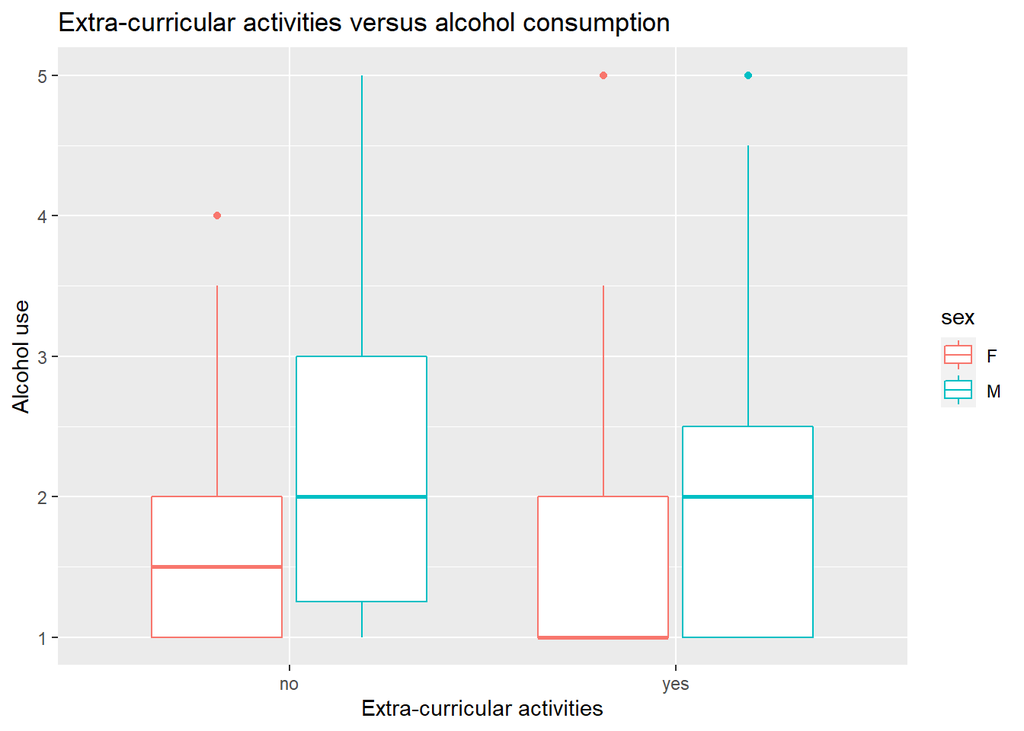

```r
# Explore relationship between extra-curricular activities and alcohol consumption:
g3 <- ggplot(alc, aes(x = activities, y = alc_use, col = sex))
g3 + geom_boxplot() + ggtitle("Extra-curricular activities versus alcohol consumption") + ylab("Alcohol use") + xlab("Extra-curricular activities")
```

I hypothesized that having extra-curricular activities would decrease drinking, but this figure is against my thoughts. Either female or male don’t have significant difference here. My assumptions have been too bad… The last guess was that alcohol consumption would decrease final grade.

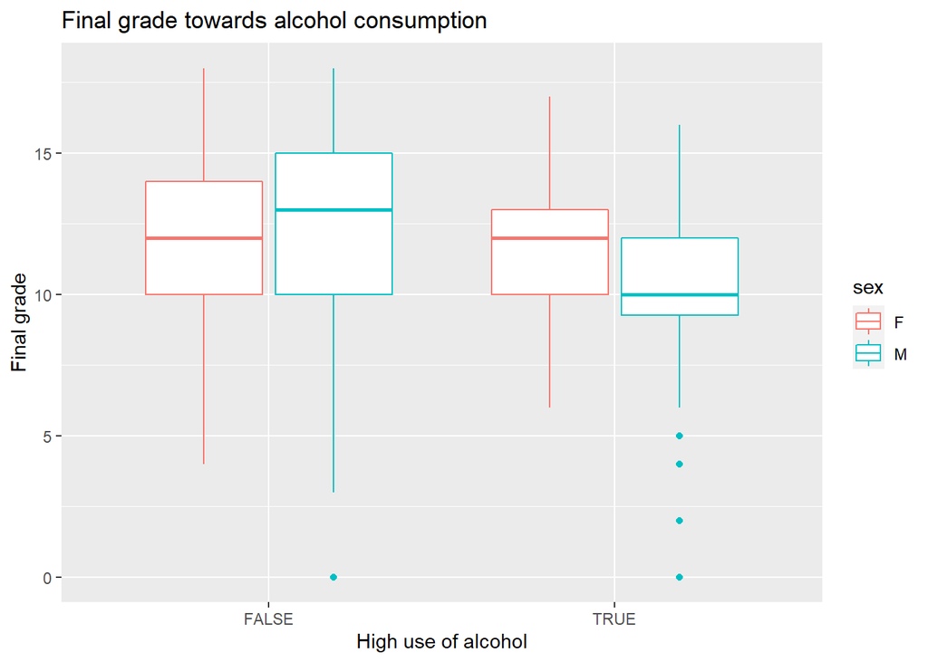

```r
# Explore relationship between final grade and alcohol consumption:
g4 <- ggplot(alc, aes(x = high_use, y = G3, col = sex))
g4 + geom_boxplot() + ggtitle("Final grade towards alcohol consumption") + xlab("High use of alcohol") + ylab("Final grade")
```

Interesting: Male students who drink a lot, have got significantly lower grades than they who are not high-users. But female students have got approximately equal grades whether they are high-users or not. So the combination of sex and final grade might help us to predict high-users by logistic regression.

### Logistic regression model:

```r
# Fit logistic regression model:
m1 <- glm(high_use ~ sex + studytime + activities + G3, data = alc, family = "binomial")
summary(m1)
```

```
##
## Call:
## glm(formula = high_use ~ sex + studytime + activities + G3, family = "binomial",
##     data = alc)
##
## Deviance Residuals:
##     Min       1Q   Median       3Q      Max
## -1.5618  -0.8334  -0.6514   1.1705   2.1916
##
## Coefficients:
##               Estimate Std. Error z value Pr(>|z|)
## (Intercept)    0.51218    0.52022   0.985  0.32485
## sexM           0.77704    0.25030   3.104  0.00191 **
## studytime     -0.41957    0.16027  -2.618  0.00885 **
## activitiesyes -0.26007    0.24134  -1.078  0.28120
## G3            -0.07127    0.03680  -1.937  0.05278 .
## ---
## Signif. codes:  0 '***' 0.001 '**' 0.01 '*' 0.05 '.' 0.1 ' ' 1
##
## (Dispersion parameter for binomial family taken to be 1)
##
##     Null deviance: 452.04  on 369  degrees of freedom
## Residual deviance: 420.16  on 365  degrees of freedom
## AIC: 430.16
##
## Number of Fisher Scoring iterations: 4
```

In the summary above we see that the intercept of the model is 0.51218, when sex is female and student has no extra-curricular activities. If student is male, the intercept increases by 0.77704 units, and if student has extra-curricular activities, the intercept decreases by 0.26007 units. Both study time and grade G3 have a negative slope, thus the increase of studying time by one criteria would decrease the probability of high-using by 0.41957 units, and the increase of G3 by one value would decrease the probability of high-using by 0.07127 units. Variables sex and study time are clearly significant parts of the model, and variable G3 less significant. However the existence of extra-curricular activities can be dropped out of the model, since there is 28 % percent risk to get the same data without any relationship between high alcohol use and extra-curricular activities.

```r
# Compute odds ratios (OR)
OR <- coef(m1) %>% exp

# Compute confidence intervals (CI)
CI <- confint(m1) %>% exp

# Print out the odds ratios with their confidence intervals
cbind(OR, CI)
```

```
##                      OR     2.5 %    97.5 %
## (Intercept)   1.6689249 0.6053506 4.6794065
## sexM          2.1750354 1.3356996 3.5699532
## studytime     0.6573270 0.4756858 0.8933087
## activitiesyes 0.7709957 0.4793976 1.2367785
## G3            0.9312065 0.8655560 1.0003113
```

In the table above I have presented odds ratios and their intervals for different explanatory variables. The odds ratios tell us for example that if student is male, his probability to be alcohol high-user is 2.175 times larger than female students. If odds ratio is less than 1 (like study time), then it’s less probable to be high-user. And if value 1 is between the confidence interval (like activities), then there is no significant evidence that having extra-curricular activities would decrease the probability being high-user.

```r
# Fit logistic regression model without non-significant variable activities:
m2 <- glm(high_use ~ sex + studytime + G3, data = alc, family = "binomial")
summary(m2)
```

```
##
## Call:
## glm(formula = high_use ~ sex + studytime + G3, family = "binomial",
##     data = alc)
##
## Deviance Residuals:
##     Min       1Q   Median       3Q      Max
## -1.5174  -0.8425  -0.6723   1.1643   2.2607
##
## Coefficients:
##             Estimate Std. Error z value Pr(>|z|)
## (Intercept)  0.47034    0.51713   0.910  0.36308
## sexM         0.74089    0.24742   2.994  0.00275 **
## studytime   -0.44010    0.15938  -2.761  0.00576 **
## G3          -0.07402    0.03664  -2.020  0.04334 *
## ---
## Signif. codes:  0 '***' 0.001 '**' 0.01 '*' 0.05 '.' 0.1 ' ' 1
##
## (Dispersion parameter for binomial family taken to be 1)
##
##     Null deviance: 452.04  on 369  degrees of freedom
## Residual deviance: 421.33  on 366  degrees of freedom
## AIC: 429.33
##
## Number of Fisher Scoring iterations: 4
```

```r
# Explore the predictive power of the model m2, first predict the probability of high_use:
probabilities <- predict(m2, type = "response")

# Add the predicted probabilities to 'alc':
alc <- mutate(alc, probability = probabilities)

# Use the probabilities to make a prediction of high_use:
alc <- mutate(alc, prediction = probability > 0.5)

# Tabulate the target variable versus the predictions:
table(high_use = alc$high_use, prediction = alc$prediction) %>% addmargins()
```

```
##         prediction
## high_use FALSE TRUE Sum
##    FALSE   246   13 259
##    TRUE     91   20 111
##    Sum     337   33 370
```

```r
# Tabulate percentages:
table(high_use = alc$high_use, prediction = alc$prediction) %>% prop.table() %>% addmargins()
```

```
##         prediction
## high_use      FALSE       TRUE        Sum
##    FALSE 0.66486486 0.03513514 0.70000000
##    TRUE  0.24594595 0.05405405 0.30000000
##    Sum   0.91081081 0.08918919 1.00000000
```

Thus, 246/259 not high-users were predicted correctly, but only 20/111 high-users were predicted correctly.

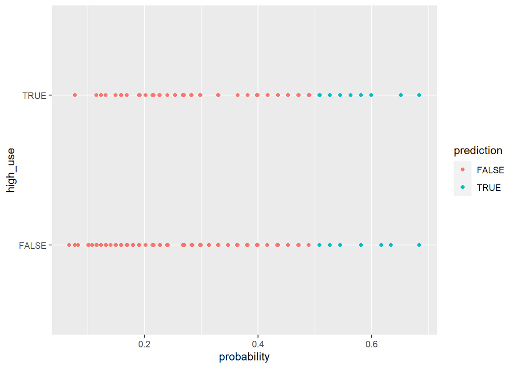

```r
# Initialize a plot of 'high_use' versus 'probability' in 'alc'
g <- ggplot(alc, aes(x = probability, y = high_use, col = prediction))

# define the geom as points and draw the plot
g + geom_point()
```

In the figure above the same phenomena is illustrated. Generally the model underestimates alcohol use, and it doesn’t recognize all high-users.

```r
# Let's then define a loss function (= mean prediction error)
loss_func <- function(class, prob) {
  n_wrong <- abs(class - prob) > 0.5
  mean(n_wrong)
}

# Call loss function to compute the average number of wrong predictions in the (training) data
loss_func(class = alc$high_use, prob = alc$probability)
```

```
## [1] 0.2810811
```

```r
# And compare the previous result to a prediction that there would have been zero high-users:
loss_func(class = alc$high_use, prob = 0)
```

```
## [1] 0.3
```

My model went wrong 28.1 % of times, but a very simple prediction would go wrong 30 % of times. Therefore my predictions were only slightly better. Having a real case I should consider testing other explanatory variables too.